# Multivariate Data

## Objectives for the week

- Introduction to multivariate data
- Plotting for mulivariate data
- Univariate vs multivariate
- Multivariate analysis techniques

This will include a brief overview of many multivariate statistical techniques, the idea is to introduce the names of techniques you may see in the future or want to investigate later.

## Multivariate data

Numerous observations or variables are obtained for each individual or unit studied.

For plotting purposes, 3 or more variables.

## Multivariate figures

You are already familiar with some techniques for displaying 3 variables: variables:

- Color
- Shape
- facet
- bubble charts (size)
- combining geoms

Useful for, 2-3 numeric variables plus 2-3 discrete variables

## Grouping

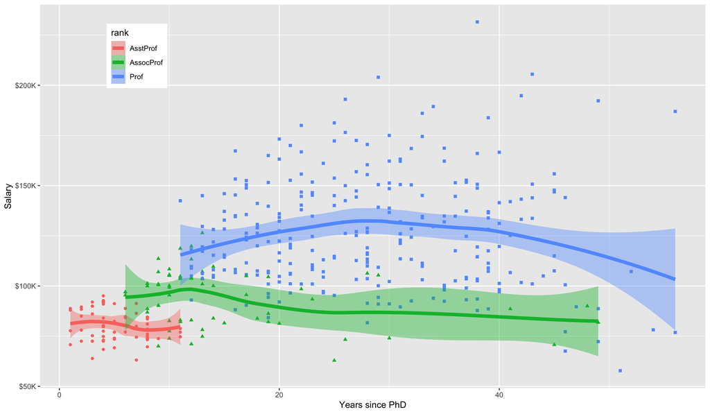

Grouping can add a 3rd dimension to any 2-D plot, using colors, shapes, or size of points/lines

## Conditioning

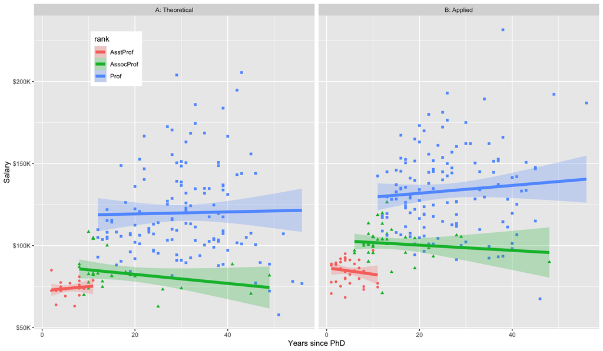

Conditioning is usually done with facets. Here we add a fourth variable by conditioning on it.

## Conditioning

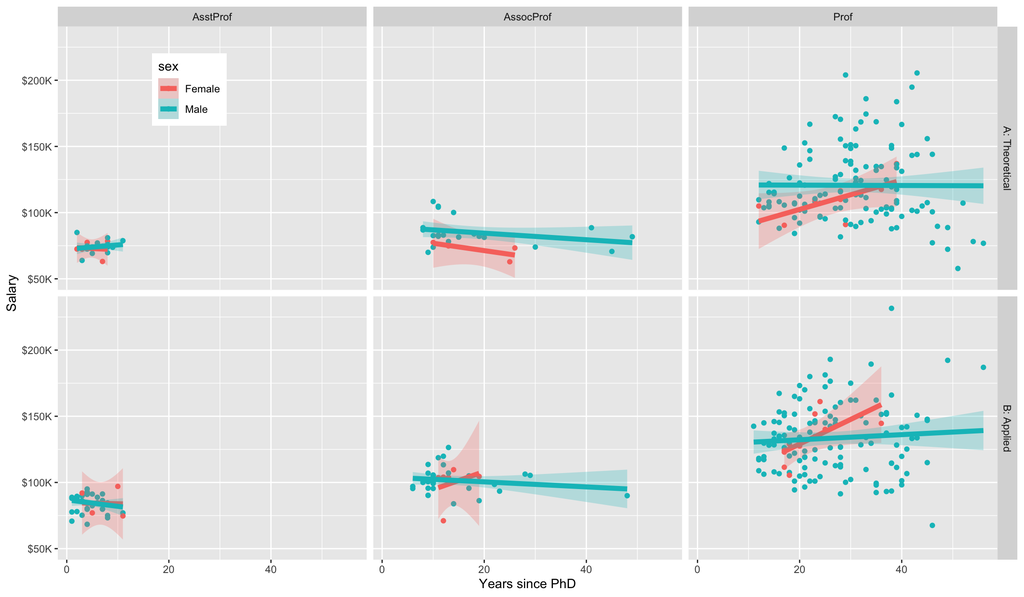

Now we are displaying 5 variables:

- Bivariate scatterplot
- add sex as color
- condition on field and position

## Multivariate figures

This week we will look at:

- correlation/scatterplot matrix
- heatmaps
- biplots
- radar plots

Sometimes appropriate options, that we won’t cover:

- 3-D scatterplots
- interactive plots

## Correlation (scatterplot) matrix

A *pairs* plot (or scatterplot matrix) displays all possible $p x p$ pairs of $p$ variables in a matrix-like display where variables $(x_{i}, x_{j})$ are shown in a plot for row $i$, column $j$.

Useful for assessing correlations, multicollinearity, and EDA across many numeric variables.

In base R this can be done with `pairs()`:

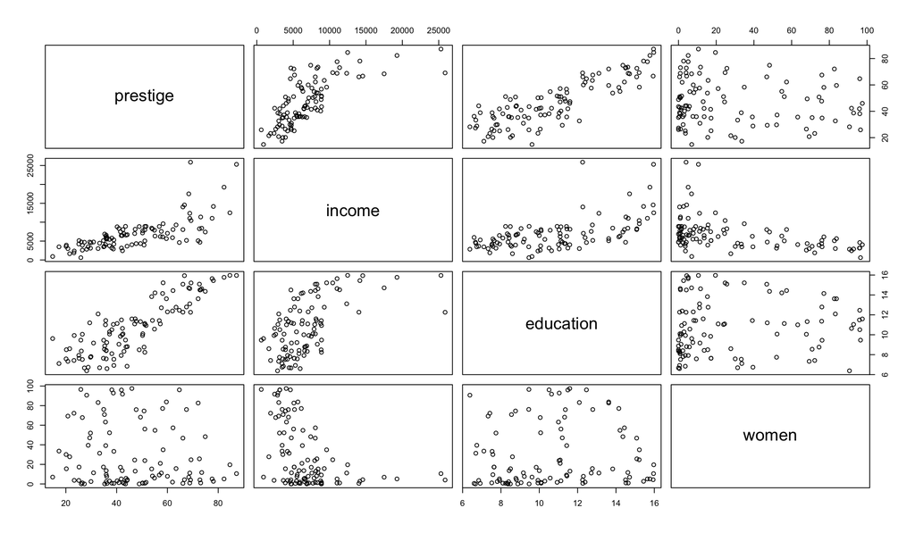

## Correlation (scatterplot) matrix

We can also use the `ggpairs()` function from the `ggplot2` and `GGally` packages in R to create a scatterplot matrix

By default these give a lot of information, but see help menu to reduce the plots shown, there are also title and label arguments (see `?ggpairs()`)

```r
library(GGally)

ggpairs(Prestige)
```

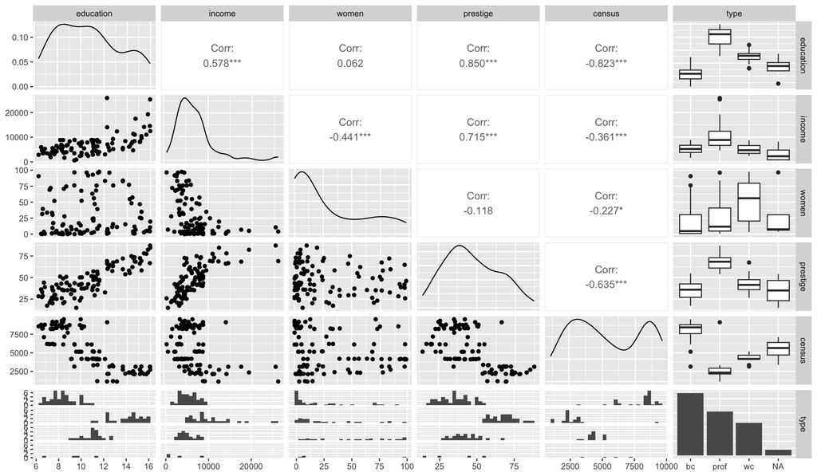

## Correlation (scatterplot) matrix

A more feature-rich version is provided by `car::scatterplotMatrix()` which can add the regression lines, loess smooths and data ellipses for each pair,

```r
library(car)
scatterplotMatrix(~ prestige + income + education + women,
  data=Prestige,
  regLine = list(method=lm, lty=1, lwd=2, col="black"),
  smooth=list(smoother=loessLine, spread=FALSE,
              lty.smooth=1, lwd.smooth=3, col.smooth="red"),
  ellipse=list(levels=0.68, fill.alpha=0.1))
```

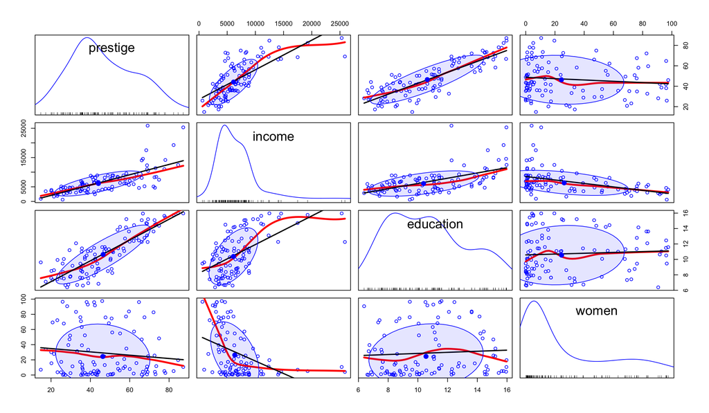

## Heat maps

A heatmap displays a set of data using colored tiles for each variable value within each observation.

Three numeric variables

Effective for identifying patterns, trends, and anomalies within large datasets

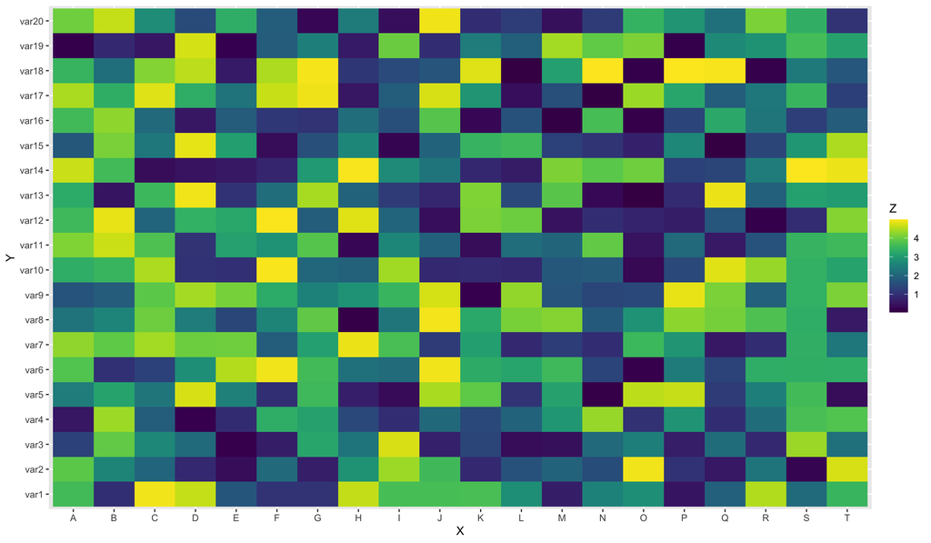

## Heat maps

There are many varieties of heatmaps

Libraries:

- Base R comes with a `heatmap()` function,
- `superheat` package,
- `geom_tile()` in `ggplot`

We will explore `geom_tile()` to stay in the `tidyverse`

## Heat maps

`scale_fill_gradient(low="white", high="blue")`

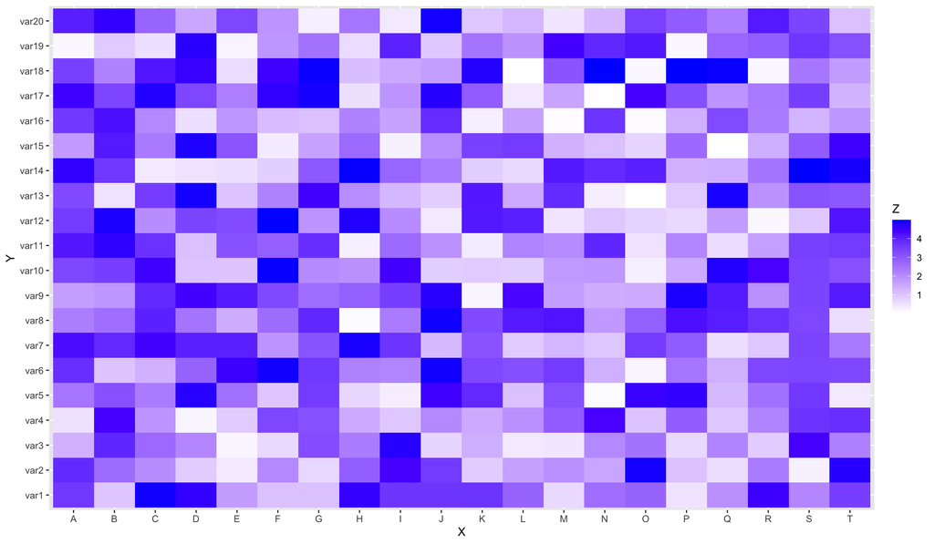

`viridis::scale_fill_viridis( )`

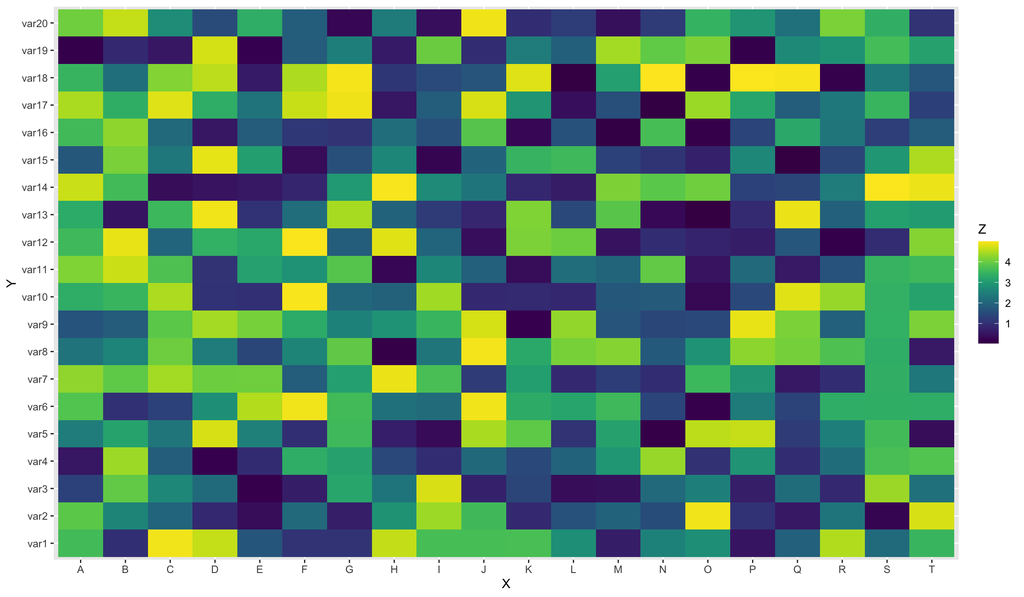

## Biplots

A biplot is a specialized graph that attempts to represent the relationship between observations, between variables, and between observations and variables, in a low (usually two) dimensional space (Nishisato et al. 2021)

For more than three quantitative variables

Usually paired with a dimension reduction analysis

Looking at distance between points, closer point = more similar data

Arrows show driving predictor variables

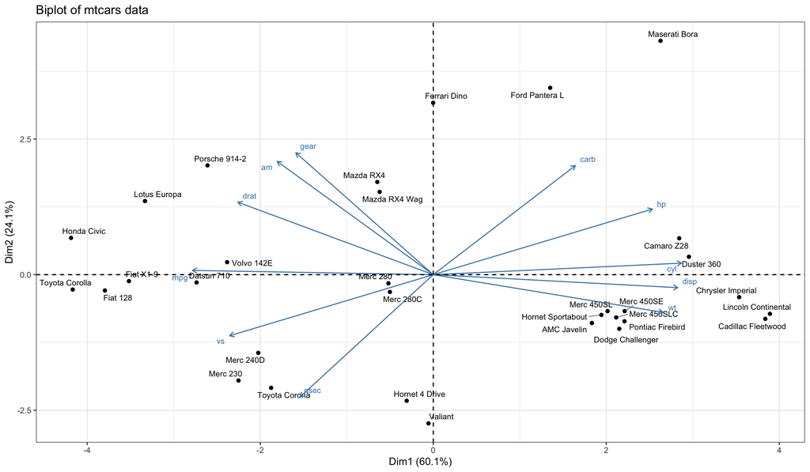

## Radar plot

A radar chart (also called a spider or star chart) displays one or more groups or observations on three or more quantitative variables.

Each variable has its own axis, all axes are joined in the center of the figure.

Library: `fmsb::radarchart()`

Input data format is very specific.

- Each row must be an entity.
- Each column is a quantitative variable.
- First 2 rows provide the min and the max that will be used for each variable.

Exam results of a student

(score 0-20 in each subject)

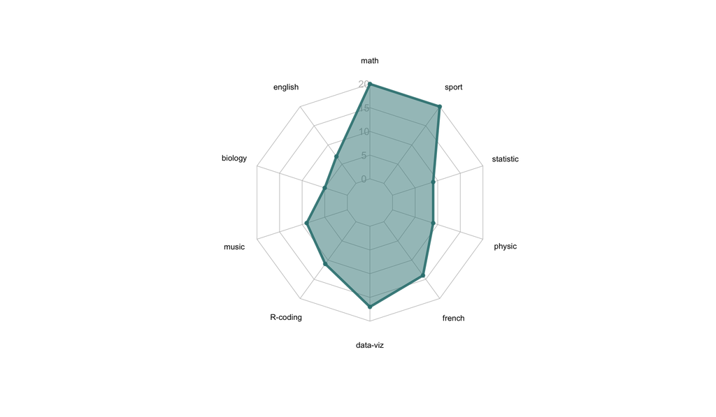

## Radar plot

Several individuals

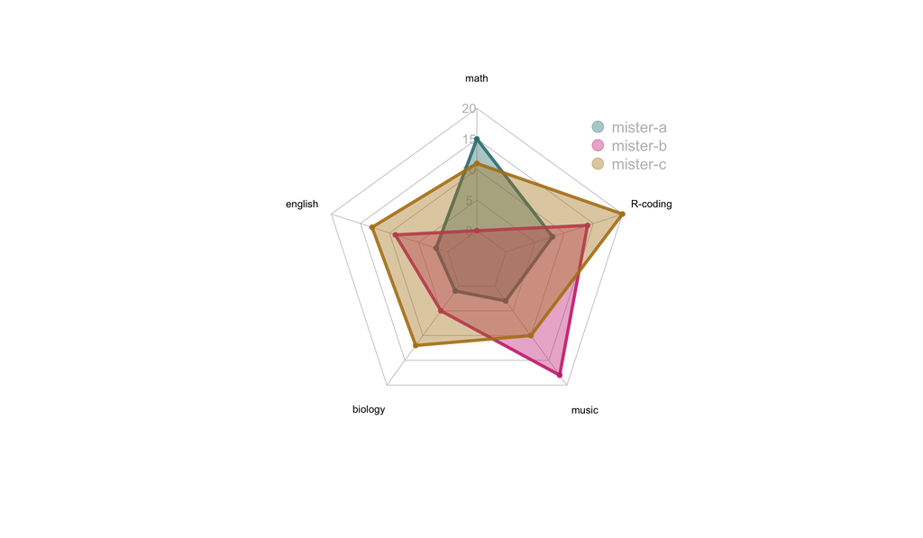

**Don’t** show more that 2 or 3 groups on the same web chart, it would make it unreadable

Better to represent as a series of radar charts instead (like facet)

## Radar plot

Spider charts are often criticized:

- Circular layout = harder to read
  - quantitative values are much easier to compare when they are laid out along a single vertical or horizontal axis.
  - people are more used to vertical or horizontal axes
- What’s high? what’s low?
  - radar charts where there are no starts and ends = harder to tell rankings quickly
- Category order has a huge impact
  - Radar chart readers will probably focus on the shape observed. This can be misleading since this shape highly depends on the ordering of categories around the plot
- Over-evaluation of differences
  - the area of a shape in a radar chart also increases quadratically rather than linearly, which could lead viewers to think that small changes are more significant than they actually are
  - people are bad at estimating changes in shapes (also a problem with bubble plots)

## Summary so far:

For plotting purposes, multivariate = 3 or more variables.

Multivariate figures:

- correlation/scatterplot matrix
- heatmaps
- biplots
- radar plots

## Mo’ data Mo’ problems

Most plots and visualizations are inherently 2 dimensions.

Add 3rd, 4th, 5th, … dimension with techniques we already discussed

What happens when you have 20, 30, etc variables?

Common in biology (genetic, protein, diversity, etc) studies, text categorization, sociology/demographic studies, and more

## Multivariate vs multivariable

Response: the response variable is one (**univariate**) or multiple (**multivariate**)

Predictor: there is one predictor (single LM) or there are multiple (multiple LM: additive or multiplicative **multivariable analysis**)

Compared to univariate methods, multivariate methods can:

- save time and effort.
- reveal patterns that cannot be seen by looking at one variable at a time.

You have (probably) already learned about models with multiple predictors.

## Buffet of analyses

Dimension reduction and ordination

- free ordination techniques (PCA, NMS, NMS Scores),
- constrained/supervised ordination techniques (RDA, dbRDA)

Cluster and classification

- classification procedures (Cluster Analysis, random forest)

Hypothesis testing

- group testing tools (MRPP, PerMANOVA, SumF, ISA),
- association assessments (Mantel Test, Compare Scores),
- ordination (RDA)

So many more then we will look at this week

## Dimension reduction

How can we integrate the information of multiple (lots!) variables?

If we can find a way to combine all the variables into two single new variables we can summarize the data into one plot.

**Dimensional Reduction** is the process of reducing the number of input variables in a dataset while retaining the most important information.

## Advantages of Dimensionality Reduction Techniques

- Improves the performance of machine learning models.
- Reduces training time and computation cost.
- Helps in removing irrelevant or duplicate features.
- Makes models less likely to overfit.
- Helps in storing and processing large datasets efficiently.
- Makes data easier to visualize in 2D or 3D.
- Reveals hidden patterns or structure in complex data.

# Principal Component Analysis (PCA)

- Produces new axes which are linear combinations of the original variables.
- The first axis explains the maximum variation in the data.
- Each successive axis is orthogonal (perpendicular) to previous axes, and explains the next largest amount of variation in the data.
- We usually plot the first 2 PC scores, and look for patterns considering the proportion of variance explained.
- There will be as many new axes as there are original variables.
- All PCs together describe all of the variation in the original data matrix, just in a different way.
- The new space is a *centred orthogonal rotation* of the old space (each PC axis is centred at zero).

## Ordination

The term **ordination** means the arrangement of units in some order relative to one another.

– Ordering of units (objects) is difficult for multivariate data. - Ordination calls for dimensionality reduction or alternatively plotting *similar* cases close together.

## When to use PCA

- Quantitative data (covariances have no meaning for qualitative data).
- Data are approx. normally distributed (reasonably symmetric with no gross outliers). *can employ transformations
- The number of variables, $p$ should be less than the number of replicates $n$.
- Avoid using if there are lots of zeros in the data or data are highly skewed.
- PCA works best to reduce dimensions when there is high correlation among variables.

## PCA as a projection

- Preserves Euclidean distances
- Does not have formal “assumptions”
- But we know that zeros “matter” as well as the scale (for PCA on covariance matrix)
- Do PCA on the correlation matrix if variables are not dimensionally homogeneous or are on different scales.
- Do PCA on the covariance matrix if variables are dimensionally homogeneous and on similar scales.
- Results are typically plotted using a biplot

## Multidimensional Scaling (MDS)

- a technique for visualizing the level of similarity or dissimilarity between observations in a lower-dimensional space, typically based on a distance matrix.
- non-metric multidimensional scaling (nMDS) is distance-based ordination technique
- Because it focuses on the distance matrix, it is very flexible – any distance measure can be used (euclidian, Brays, etc)

Clarke (1993, p. 117-126)

## When to use nMDS

- Common technique for biological, ecological, psycological data (Shepard 1962a,b; Kruskal 1964a,b)
- The data matrix (n sample units × p species) is converted into an n x n distance matrix (or, more generally, a dissimilarity matrix).
- Does a good job at representing complex multi-dimensional data in a small number of dimensions (usually 2 or 3).
- Often used for data reduction and visualization.

## Not an ordinary ordination

NMDS differs in several important ways from other ordination techniques:

- distance-based technique
- does not plot the distances per se among sample units: attempts to plot sample units in such a way that the distances among sample units in the ordination space are in the same rank order as the distances among sample units as measured by the original distance matrix.
- It can proceed even if some distances are missing
- The axes of an NMDS ordination are entirely arbitrary, and plots may be freely rotated, centered, or inverted to increase interpretability.
- It is iterative - the positions of the sample units in ordination space are adjusted through a series of steps. `set.seed()` for reproducibility. Measure usefulness as ‘stress’
- Computationally intensive to run with very large samples.
- User must specify how many dimension
- There is no singular solution!

## Classification techniques

## Cluster Analysis

- Cluster analysis or clustering is the task of grouping a set of objects in such a way that objects in the same group (called a cluster) are more similar (in some sense or another) to each other than to those in other groups (clusters). Legendre & Legendre (2012, ch. 8)
- It is a main task of exploratory data mining, and a common technique for statistical data analysis, used in many fields.
- Can be done hierarchically or for a pre-specified number of groups (k-means)

## Plotting a cluster analysis

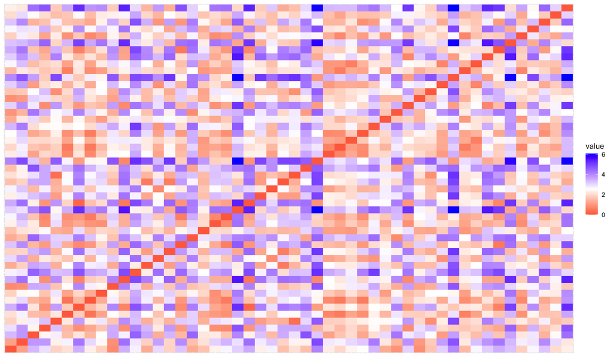

`USArrests` data: arrests per 100,000 residents for violent crime in each state in 1973

## Dendograms

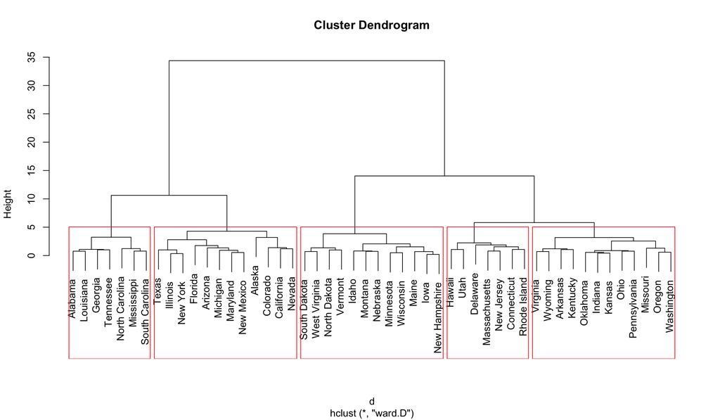

## How many clusters?

K-means clustering is the most popular partitioning method

K-means needs you to commit to a number of clusters, k, up front — but the data should decide that, not you.

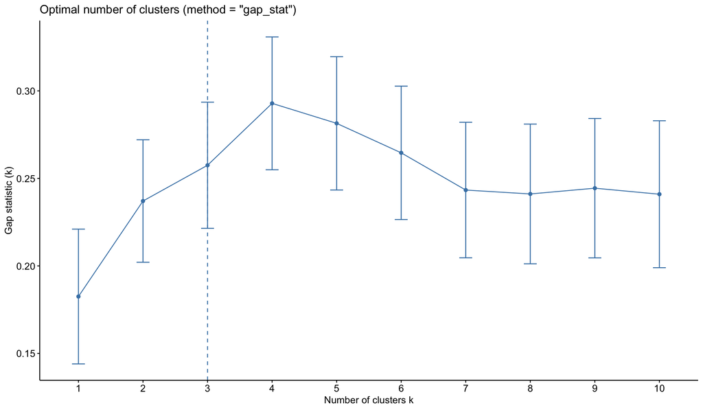

## Plotting k-means clusters

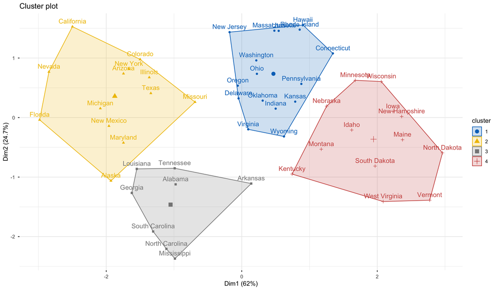

## Discriminant Analysis

Used to classify individuals into one of two or more alternative groups (or populations) on the basis of a set of measurements

It finds the directions in predictor space that best separate the classes, then assigns each observation to the class it most resembles

Linear Discriminant Analysis (LDA) finds the linear combinations of the predictors — that maximize the separation *between* classes relative to the spread *within* classes.

classic route is `MASS::lda()`

## Plot the Discriminant Analysis

Defining picture of Linear Discriminant Analysis (LDA) is the projection

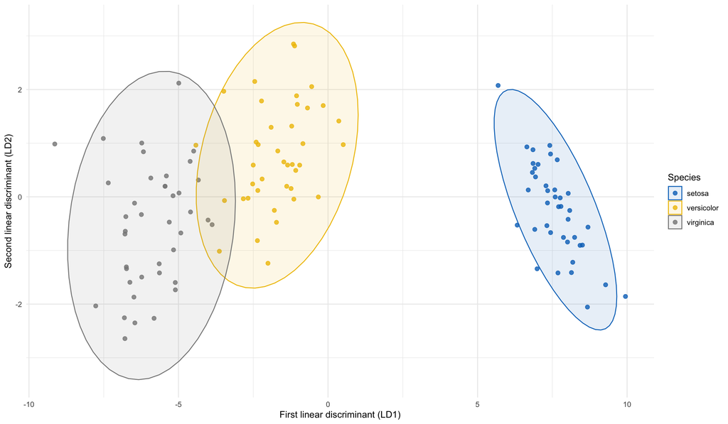

## Classification and regression trees

Used to classify observations into groups based on a response (or matrix of responses) together with one or more explanatory variables.

Classification trees are powerful tools for predictive modeling in machine learning, particularly for categorical outcomes

Non-parametric method

## Grow your tree

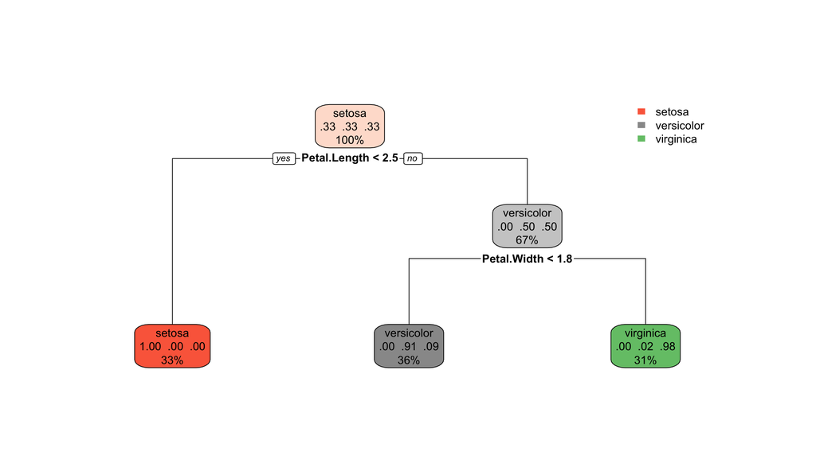

Each node shows:

- the predicted class (setosa, versicolor, virginica),
- the predicted probability of each class,
- the percentage of observations in the node

## Relationships between multivariate datasets

## RDA

- Redundancy Analysis (RDA) is a multivariate statistical technique used to explore the relationship between two sets of variables: response variables and predictor variables
- Common in ecological and environmental research to understand the influence of predictor variables on the variation in response variables.
- The main purpose is to determine the linear combinations of the predictor variables that explain the maximum amount of variation in the response variables.

## How does an RDA work?

- Starts by calculating the PCA of the predictor variables (independent variables) to reduce their dimensionality
- Then, RDA performs a constrained ordination analysis using reduced predictor variables and the response variable
- Supervised learning technique (PCA is unsupervised)

## Why use an RDA?

- It allows us to assess the significance of each predictor variable in explaining the variation in the response using the techniques such as permutation tests.
- Provides statistical tests to determine the significance of the overall model and individual predictor variables.

## MANOVA and PerMANOVA

MANOVA stands for Multivariate (or Multiple) Analysis of Variance

- multiple response variables, and you want to test whether any of them differ across levels of your explanatory variable(s) (i.e., your groups).
- Null hypothesis: that the means of each response variable are equal at every level of the explanatory variable(s);
- Alternative: that at least one response variable differs.
- Restrictive assumptions
- Often plotted with standard `ggplot` methods for showing multiple variables

Permutational Multivariate Analysis of Variance (PERMANOVA)

- developed by Marti Anderson (just returned to Massey)
- uses a distance matrix
- Calculates the pseudo F-ratio: the ratio of the variation between centroids to the variation within clusters
- no assumption of normality!
- Permutation: shuffles our data randomly, re-compute F ratio, and repeat these two steps many times, saving the F each time
- Compare this F ratio to a null distribution of Fs
- Results often plotted with a biplot

## Summary

Many, many types of multivariate statistics

Many, many types of multivariate plots

New plots:

- biplots
- VAT plots
- dendograms
- elipses on scatter plots
- trees

## References

Anderson, M.J., 2014. Permutational multivariate analysis of variance (PERMANOVA). Wiley statsref: statistics reference online, pp.1-15.

Clarke, K.R. 1993. Non-parametric multivariate analyses of changes in community structure. Australian Journal of Ecology 18:117-143.

Legendre, P., and M.J. Anderson. 1999. Distance-based redundancy analysis: testing multispecies responses in multifactorial ecological experiments. Ecological Monographs 69:1-24.

Kruskal, J.B. 1964a. Multidimensional scaling by optimizing goodness of fit to a nonmetric hypothesis. Psychometrika 29:1-27.

Kruskal, J.B. 1964b. Nonmetric multidimensional scaling: a numerical method. Psychometrika 29:115-129.

Legendre, P., and L. Legendre. 2012. Numerical Ecology. Third English edition. Elsevier, Amsterdam, The Netherlands.

Nishisato, Shizuhiko, Eric J. Beh, Rosaria Lombardo, and Jose G. Clavel. 2021. “History of the Biplot.” Book Section. In Modern Quantification Theory: Joint Graphical Display, Biplots, and Alternatives, edited by Shizuhiko Nishisato, Eric J. Beh, Rosaria Lombardo, and Jose G. Clavel, 167–79. Singapore: Springer Singapore. https://doi.org/10.1007/978-981-16-2470-4_9.

Shepard, R.N. 1962a. The analysis of proximities: multidimensional scaling with an unknown distance function. I. Psychometrika 27:125–140.

Shepard, R.N. 1962b. The analysis of proximities: multidimensional scaling with an unknown distance function. II. Psychometrika 27:219-246.